# Estimating the Causal Effect of Pandemic-Induced League Shutdowns on Hockey Prospect Development

Background Walk-Through

Jackie Jovanovic

September 20th, 2022

## Introduction

**Project Motivation**: Investigate the impact of pandemic restrictions on hockey player development.

During 2020-2021, many hockey leagues (including NHL feeder leagues) had shortened seasons or no season due to the restrictions on play caused by the COVID-19 pandemic. Some players experiencing restrictions played in other leagues or tournaments during the 2020-21 season. Others did not play any league/tournament games during the 2020-21 season. This poses the question of whether not playing games during the 2020-2021 COVID season negatively impacted player development (or caused players to get worse).

To answer this question, we will examine data from the Ontario Hockey League, which did not play any games during the 2020-21 season. Some players from this league played in other leagues or tournaments while others did not.

## Data

Our dataset is comprised of players who played in the Ontario Hockey League (OHL) during both the pre-COVID (2019-2020) and post-COVID (2021-2022) seasons. The dataset also includes information regarding other leagues they have played in during their career. There is information regarding season, team, league, points, games played, position, and drafted status. Each row is a player on a certain team in a specific season.

The data was was sourced from Elite Prospects and was supplied by our external advisor, Dr. Sam Ventura.

*Note: I know the this introduction will have to change depending on the dataset used in the final version.*

### Load the original data and explore:

```r
sams_ohl_data_request <- read_csv("sams_ohl_data_request.csv")
```

```
## ──────────────────────────────────────────────────────── Delimiter: "," chr
## (13): team_name, season, league, first_name, last_name, name, player_ty... dbl
## (14): ...1, player_id, gp, g, a, pts, pim, pm, weight_metric, weight_im... date
## (1): dob
```

```r
skim(sams_ohl_data_request)
```

Data summary

| Name | sams_ohl_data_request |
| --- | --- |
| Number of rows | 11690 |
| Number of columns | 28 |
| _______________________ |  |
| Column type frequency: |  |
| character | 13 |
| Date | 1 |
| numeric | 14 |
| ________________________ |  |
| Group variables | None |

**Variable type: character**

| skim_variable | n_missing | complete_rate | min | max | empty | n_unique | whitespace |
| --- | --- | --- | --- | --- | --- | --- | --- |
| team_name | 0 | 1.00 | 4 | 31 | 0 | 465 | 0 |
| season | 0 | 1.00 | 9 | 9 | 0 | 40 | 0 |
| league | 0 | 1.00 | 2 | 25 | 0 | 159 | 0 |
| first_name | 0 | 1.00 | 2 | 12 | 0 | 795 | 0 |
| last_name | 0 | 1.00 | 2 | 18 | 0 | 2642 | 0 |
| name | 0 | 1.00 | 7 | 24 | 0 | 3311 | 0 |
| player_type | 0 | 1.00 | 6 | 10 | 0 | 2 | 0 |
| position | 0 | 1.00 | 1 | 1 | 0 | 3 | 0 |
| shoots | 68 | 0.99 | 1 | 1 | 0 | 2 | 0 |
| youth_team | 8472 | 0.28 | 2 | 30 | 0 | 481 | 0 |
| nationality | 0 | 1.00 | 3 | 3 | 0 | 25 | 0 |
| height_imperial | 2 | 1.00 | 4 | 5 | 0 | 16 | 0 |
| draft_team_name | 8330 | 0.29 | 12 | 21 | 0 | 33 | 0 |

**Variable type: Date**

| skim_variable | n_missing | complete_rate | min | max | median | n_unique |
| --- | --- | --- | --- | --- | --- | --- |
| dob | 0 | 1 | 1964-07-04 | 2005-12-20 | 1994-03-03 | 2680 |

**Variable type: numeric**

| skim_variable | n_missing | complete_rate | mean | sd | p0 | p25 | p50 | p75 | p100 | hist |
| --- | --- | --- | --- | --- | --- | --- | --- | --- | --- | --- |
| …1 | 0 | 1.00 | 4881.44 | 3234.41 | 0 | 1863.25 | 4785.5 | 7707.75 | 10630 | ▇▆▆▆▆ |
| player_id | 0 | 1.00 | 183680.37 | 198210.75 | 137 | 23104.00 | 92680.5 | 274015.00 | 796686 | ▇▃▁▁▁ |
| gp | 1 | 1.00 | 42.70 | 21.98 | 1 | 26.00 | 50.0 | 62.00 | 74 | ▅▃▃▅▇ |
| g | 21 | 1.00 | 9.29 | 10.88 | 0 | 1.00 | 5.0 | 14.00 | 72 | ▇▂▁▁▁ |
| a | 21 | 1.00 | 14.86 | 14.76 | 0 | 3.00 | 10.0 | 22.00 | 104 | ▇▂▁▁▁ |
| pts | 21 | 1.00 | 24.15 | 24.36 | 0 | 5.00 | 16.0 | 36.00 | 162 | ▇▂▁▁▁ |
| pim | 39 | 1.00 | 38.00 | 37.05 | 0 | 11.00 | 28.0 | 54.00 | 286 | ▇▂▁▁▁ |
| pm | 1174 | 0.90 | 0.13 | 14.29 | -72 | -7.00 | -1.0 | 6.00 | 70 | ▁▁▇▂▁ |
| weight_metric | 2 | 1.00 | 87.94 | 7.72 | 64 | 83.00 | 88.0 | 93.00 | 116 | ▁▅▇▂▁ |
| weight_imperial | 2 | 1.00 | 193.86 | 16.98 | 141 | 183.00 | 194.0 | 205.00 | 256 | ▁▆▇▂▁ |
| height_metric | 2 | 1.00 | 184.66 | 5.69 | 168 | 180.00 | 185.0 | 188.00 | 205 | ▁▃▇▂▁ |
| draft_year | 8330 | 0.29 | 2011.02 | 6.05 | 2000 | 2006.00 | 2011.0 | 2016.00 | 2021 | ▆▆▇▇▇ |
| round | 8330 | 0.29 | 3.76 | 2.06 | 1 | 2.00 | 4.0 | 5.00 | 9 | ▇▇▃▅▁ |
| overall_pick_num | 8330 | 0.29 | 101.22 | 65.58 | 1 | 44.00 | 94.0 | 154.00 | 283 | ▇▇▆▃▁ |

### Data filtered to the three seasons of interest (2019-2020, 2020-2021, 2021-2022):

```r
# filter years
recent <- sams_ohl_data_request %>%
  filter(season %in% c("2019-2020", "2020-2021", "2021-2022"))
```

Both the ‘sams_ohl_data_request’ and ‘recent’ data frames are not currently being used in this file. They were used in analysis in other files.

## ohl_filtered

Here is the link the GitHub file with a breakdown of how ohl_filtered was created: https://github.com/jajovanovic/CMSAC-NHL-COVID-Impact/blob/main/meeting-files/Sam-Meeting-7-idk-22/Sam-Meeting-7-idk-22.Rmd or https://github.com/jajovanovic/CMSAC-NHL-COVID-Impact/blob/main/CMSACamp-Final-Report.Rmd

### Variables added:

```r
ohl_filtered <- read_csv("ohl_filtered.csv")
ohl_filtered <- ohl_filtered %>%
  mutate(got_drafted = case_when(!is.na(draft_year) & draft_year < 2020
                                 ~ 'Yes',
                                 TRUE ~ 'No'))

# convert treatment to binary indicator:
ohl_filtered <- ohl_filtered %>%
  mutate(treatment = ifelse(treatment == "Played", 1, 0),
         treatment = as.integer((treatment)))

# convert categorical variables to binary
ohl_update <- ohl_filtered %>%
  mutate(is_forward = case_when(position == "F" ~ 1,
                                position == "D" ~ 0)) %>%
  mutate(is_drafted = case_when(got_drafted == "Yes" ~ 1,
                                got_drafted == "No" ~ 0)) %>%
  mutate(s_played = case_when(season == "2021-2022" ~ 1,
                              season == "2019-2020" ~ 0)) %>%
  as.data.frame()
skim(ohl_update)
```

Data summary

| Name | ohl_update |
| --- | --- |
| Number of rows | 219 |
| Number of columns | 26 |
| _______________________ |  |
| Column type frequency: |  |
| character | 5 |
| logical | 2 |
| numeric | 19 |
| ________________________ |  |
| Group variables | None |

**Variable type: character**

| skim_variable | n_missing | complete_rate | min | max | empty | n_unique | whitespace |
| --- | --- | --- | --- | --- | --- | --- | --- |
| season | 0 | 1 | 9 | 9 | 0 | 1 | 0 |
| first_name | 0 | 1 | 2 | 11 | 0 | 145 | 0 |
| last_name | 0 | 1 | 3 | 18 | 0 | 210 | 0 |
| position | 0 | 1 | 1 | 1 | 0 | 2 | 0 |
| got_drafted | 0 | 1 | 2 | 3 | 0 | 2 | 0 |

**Variable type: logical**

| skim_variable | n_missing | complete_rate | mean | count |
| --- | --- | --- | --- | --- |
| championship | 0 | 1 | 0.05 | FAL: 207, TRU: 12 |
| drafted | 0 | 1 | 0.09 | FAL: 200, TRU: 19 |

**Variable type: numeric**

| skim_variable | n_missing | complete_rate | mean | sd | p0 | p25 | p50 | p75 | p100 | hist |
| --- | --- | --- | --- | --- | --- | --- | --- | --- | --- | --- |
| player_id | 0 | 1.00 | 471615.01 | 109026.03 | 201722.00 | 418057.50 | 502940.00 | 532978.00 | 652095.00 | ▂▂▅▇▅ |
| gp_19_20 | 0 | 1.00 | 46.86 | 17.27 | 1.00 | 42.00 | 53.00 | 58.00 | 67.00 | ▂▁▂▅▇ |
| age | 0 | 1.00 | 18.89 | 0.76 | 17.00 | 18.00 | 19.00 | 19.00 | 20.00 | ▁▆▁▇▅ |
| pts_19_20 | 0 | 1.00 | 18.22 | 16.36 | 0.00 | 6.00 | 13.00 | 28.00 | 80.00 | ▇▃▂▁▁ |
| ppg_19_20 | 0 | 1.00 | 0.35 | 0.27 | 0.00 | 0.14 | 0.27 | 0.50 | 1.29 | ▇▅▂▁▁ |
| draft_year | 174 | 0.21 | 2020.51 | 0.63 | 2019.00 | 2020.00 | 2021.00 | 2021.00 | 2021.00 | ▁▁▅▁▇ |
| round | 174 | 0.21 | 3.82 | 1.86 | 1.00 | 2.00 | 4.00 | 5.00 | 7.00 | ▇▂▅▅▆ |
| overall_pick_num | 174 | 0.21 | 106.16 | 59.49 | 3.00 | 48.00 | 121.00 | 153.00 | 217.00 | ▇▃▇▆▃ |
| age_continuous | 0 | 1.00 | 19.51 | 0.78 | 17.99 | 18.82 | 19.53 | 19.99 | 20.98 | ▅▇▇▇▅ |
| pm_relative_19_20 | 0 | 1.00 | -3.36 | 9.30 | -26.33 | -10.08 | -3.74 | 2.61 | 19.77 | ▁▆▇▅▂ |
| pm_rank_19_20 | 0 | 1.00 | 15.31 | 7.08 | 1.00 | 10.00 | 16.00 | 21.00 | 31.00 | ▅▅▇▆▂ |
| pm_19_20 | 0 | 1.00 | -4.82 | 12.48 | -41.00 | -12.00 | -2.00 | 2.00 | 26.00 | ▂▃▇▇▂ |
| treatment | 0 | 1.00 | 0.31 | 0.46 | 0.00 | 0.00 | 0.00 | 1.00 | 1.00 | ▇▁▁▁▃ |
| ppg_21_22 | 0 | 1.00 | 0.64 | 0.41 | 0.00 | 0.31 | 0.57 | 0.91 | 1.82 | ▇▇▆▃▁ |
| gp_covid | 0 | 1.00 | 5.02 | 10.06 | 0.00 | 0.00 | 0.00 | 4.50 | 56.00 | ▇▁▁▁▁ |
| gp_21_22 | 0 | 1.00 | 48.94 | 19.22 | 2.00 | 36.00 | 57.00 | 65.00 | 68.00 | ▂▁▂▂▇ |
| is_forward | 0 | 1.00 | 0.63 | 0.48 | 0.00 | 0.00 | 1.00 | 1.00 | 1.00 | ▅▁▁▁▇ |
| is_drafted | 0 | 1.00 | 0.01 | 0.12 | 0.00 | 0.00 | 0.00 | 0.00 | 1.00 | ▇▁▁▁▁ |
| s_played | 0 | 1.00 | 0.00 | 0.00 | 0.00 | 0.00 | 0.00 | 0.00 | 0.00 | ▁▁▇▁▁ |

Following the guidelines of https://cran.r-project.org/web/packages/tidytreatment/vignettes/use-tidytreatment-BART.html

### Fitting variable selection model

Regress outcome against covariates (excluding treatment variable)

Uses the **wbart** function: https://www.rdocumentation.org/packages/BART/versions/2.9/topics/wbart

variables included: games played, points, age, position, draft status

possible variables to include: championship (note to self: would need to convert to binary) *which pm variables should be included? : pm, pm_rank, pm_relative*

We are predicting points per game using games played, points, age, plus-minus, position, and draft status.

```r
# fit variable selection model
var_select_bart <- wbart(x.train = dplyr::select(ohl_update, gp_19_20,
                                                 pts_19_20, age_continuous,
                                                 pm_relative_19_20, pm_19_20,
                                                 is_forward, is_drafted,
                                                 ppg_19_20),
                       y.train = pull(ohl_update, ppg_21_22),
                       sparse = TRUE,
                       ntree = 25,
                       ndpost = 50)
# without draft
var_select_bart_nodr <- wbart(x.train = dplyr::select(ohl_update, gp_19_20,
                                                 pts_19_20, age_continuous,
                                                 pm_relative_19_20, pm_19_20,
                                                 is_forward, ppg_19_20),
                       y.train = pull(ohl_update, ppg_21_22),
                       sparse = TRUE,
                       ntree = 25,
                       ndpost = 50)
```

I used ntree = 25 and ndpost = 50 because I was trying to follow the steps in https://bayesiancomputationbook.com/markdown/chp_07.html#fitting-bayesian-additive-regression-trees And I figured the smaller size would make it less likely for R to crash. In the original version (from this summer), I used nskip = 2000 and ndpost = 5000. I’m not sure which is better because I do not know the what those numbers usually are.

*review output - something with tree draws?*

### Selecting subset of covariate from the VS model

Select most important vars from y ~ covariates model

```r
# variable selection
covar_ranking <- covariate_importance(var_select_bart)
var_select <- covar_ranking %>%
  filter(avg_inclusion >= quantile(avg_inclusion, 0.5)) %>%
  pull(variable)

# without draft
covar_ranking_nodr <- covariate_importance(var_select_bart_nodr)
var_select_nodr <- covar_ranking_nodr %>%
  filter(avg_inclusion >= quantile(avg_inclusion, 0.5)) %>%
  pull(variable)
```

covariate_importance description: “inclusion metric for bartMachine and BART are scaled different. bartMachine averaged over number of trees, in addition to number of MCMC draws.”

### Fitting propensity score model

A probit/logit model estimating the propensity score using only the covariates selected in the previous step. Regress z ~ selected covariates

Uses the **pbart** function: https://www.rdocumentation.org/packages/BART/versions/2.9/topics/pbart

```r
# fit a propensity score model
prop_bart <- pbart(x.train = dplyr::select(ohl_update, all_of(var_select)),
                  y.train = pull(ohl_update, treatment),
                  nskip = 2000,
                  ndpost = 5000)

# store propensity score in data
ohl_update$prop_score <- prop_bart$prob.train.mean

# copy of ohl_update
ohl_update2 <- ohl_update
# without draft
prop_bart_nodr <- pbart(x.train = dplyr::select(ohl_update2,
                                                all_of(var_select_nodr)),
                  y.train = pull(ohl_update2, treatment),
                  nskip = 2000,
                  ndpost = 5000)
ohl_update2$prop_score <- prop_bart_nodr$prob.train.mean
```

### Fitting the treatment effect model

Using the original covariates and propensity score from step 3. Regress y ~ z + covariates + propensity score

```r
# fit the treatment effect model
# te_model <- wbart(x.train = dplyr::select(ohl_update, gp_19_20, pts_19_20,
#                                   age_continuous, pm_relative_19_20,
#                                   pm_rank_19_20, pm_19_20, is_forward,
#                                   is_drafted, treatment, prop_score),
#                                   # need to include treatment and prop score
#                  y.train = pull(ohl_update, ppg_19_20),
#                  nskip = 10000L,
#                  ndpost = 200L,
#                  keepevery = 100L)
te_model <- wbart(x.train = dplyr::select(ohl_update, gp_19_20, pts_19_20,
                                  age_continuous, pm_relative_19_20,
                                  pm_19_20, is_forward,
                                  is_drafted, ppg_19_20, treatment, prop_score),
                                  # need to include treatment and prop score
                 y.train = pull(ohl_update, ppg_21_22),
                 nskip = 10000L,
                 ndpost = 200L,
                 keepevery = 100L)

# without draft
te_model_nodr <- wbart(x.train = dplyr::select(ohl_update2, gp_19_20, pts_19_20,
                                  age_continuous, pm_relative_19_20,
                                  pm_19_20, is_forward,
                                  ppg_19_20, treatment, prop_score),
                                  # need to include treatment and prop score
                 y.train = pull(ohl_update2, ppg_21_22),
                 nskip = 10000L,
                 ndpost = 200L,
                 keepevery = 100L)
```

Many of these functions produce data types that are exclusive to that specific function - the ‘wbart’ function returns the an object of type ‘wbart’, which is basically a list. Because of this I’m not sure what other functions (that are not in the tidytreatment outline) are compatible with these objects.

#### Question:

What data should I use for this? If I used the full original data, there will be the issue of multiple columns for one player in one season (if they played with multiple teams/leagues). The way I know how to fix that would cut out a lot of the variables. To combine player rows would I have to do summarize, for things like games played and points, then add the other columns (like name and draft year) back in. One problem with this method is I won’t be able to look at league or team to draw conclusions concerning those things.

*Working on this now following the guidelines from last weeks discussion.*

### Extract the posterior

```r
# extract the posterior
posterior_fitted <- fitted_draws(te_model, value = "fit",
                                 include_newdata = FALSE)
posterior_fitted
```

```
## # A tibble: 43,800 × 5
## # Groups:   .row [219]
##     .row .chain .iteration .draw   fit
##    <int>  <int>      <int> <int> <dbl>
##  1     1     NA         NA     1 0.308
##  2     2     NA         NA     1 1.13
##  3     3     NA         NA     1 0.202
##  4     4     NA         NA     1 0.337
##  5     5     NA         NA     1 1.28
##  6     6     NA         NA     1 1.21
##  7     7     NA         NA     1 0.345
##  8     8     NA         NA     1 0.794
##  9     9     NA         NA     1 0.923
## 10    10     NA         NA     1 0.642
## # … with 43,790 more rows
```

```r
# function to tidy predicted draws and add random normal noise by default
posterior_pred <- predicted_draws(te_model, include_newdata = FALSE)

# without draft
posterior_fitted_nodr <- fitted_draws(te_model_nodr, value = "fit",
                                 include_newdata = FALSE)
posterior_fitted_nodr
```

```
## # A tibble: 43,800 × 5
## # Groups:   .row [219]
##     .row .chain .iteration .draw   fit
##    <int>  <int>      <int> <int> <dbl>
##  1     1     NA         NA     1 0.337
##  2     2     NA         NA     1 1.09
##  3     3     NA         NA     1 0.300
##  4     4     NA         NA     1 0.290
##  5     5     NA         NA     1 1.20
##  6     6     NA         NA     1 1.06
##  7     7     NA         NA     1 0.318
##  8     8     NA         NA     1 0.932
##  9     9     NA         NA     1 0.819
## 10    10     NA         NA     1 0.662
## # … with 43,790 more rows
```

```r
posterior_pred_nodr <- predicted_draws(te_model_nodr, include_newdata = FALSE)
```

**fitted_draws** has been deprecated. It is from the tidybayes package. Here is the documentation: https://www.rdocumentation.org/packages/tidybayes/versions/1.1.0/topics/add_fitted_draws The help menu gave other functions that can be used instead of fitted_draws, but I am not sure which one to use because I don’t know what to values to use. I was going to try both functions out and compare the results to what was produced from fitted_draws but then I ran into the issue with the arguments.

```r
#add_epred_draws(posterior_pred, te_model)
# returns the error: "no applicable method for posterior_epred' applied ot an object of class 'wbart'"
```

### Plot with **tidybayes**

#### Position

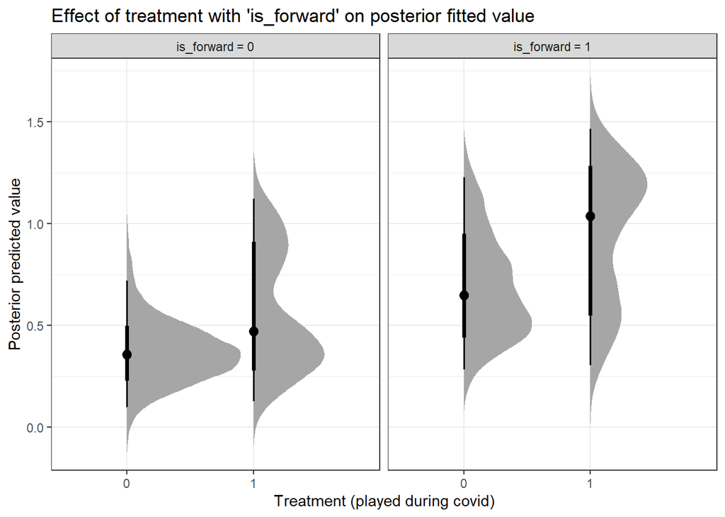

```r
# plots using tidybayes
treatment_var_and_c1 <- ohl_update %>%
  dplyr::select(treatment, is_forward) %>%
  mutate(.row = 1:n(), treatment = as.factor(treatment))

posterior_fitted %>%
  left_join(treatment_var_and_c1, by = ".row") %>%
  ggplot() +
  stat_halfeye(aes(x = treatment, y = fit)) +
  facet_wrap(~is_forward, labeller =
               as_labeller( function(x) paste("is_forward =",x) ) ) +
  xlab("Treatment (played during covid)") + ylab("Posterior predicted value") +
  theme_bw() +
  ggtitle("Effect of treatment with 'is_forward' on posterior fitted value")
```

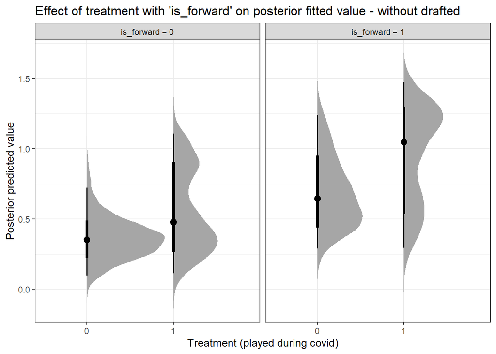

```r
# without draft
treatment_var_and_c1_nodr <- ohl_update2 %>%
  dplyr::select(treatment, is_forward) %>%
  mutate(.row = 1:n(), treatment = as.factor(treatment))
posterior_fitted_nodr %>%
  left_join(treatment_var_and_c1_nodr, by = ".row") %>%
  ggplot() +
  stat_halfeye(aes(x = treatment, y = fit)) +
  facet_wrap(~is_forward, labeller =
               as_labeller( function(x) paste("is_forward =",x) ) ) +
  xlab("Treatment (played during covid)") + ylab("Posterior predicted value") +
  theme_bw() +
  ggtitle("Effect of treatment with 'is_forward' on posterior fitted value - without drafted")
```

#### Age

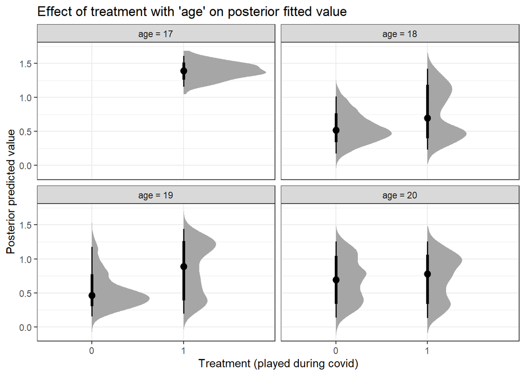

```r
# plots using tidybayes
treatment_var_and_c1 <- ohl_update %>%
  dplyr::select(treatment, age) %>%
  mutate(.row = 1:n(), treatment = as.factor(treatment))

posterior_fitted %>%
  left_join(treatment_var_and_c1, by = ".row") %>%
  ggplot() +
  stat_halfeye(aes(x = treatment, y = fit)) +
  facet_wrap(~age, labeller =
               as_labeller( function(x) paste("age =",x) ) ) +
  xlab("Treatment (played during covid)") + ylab("Posterior predicted value") +
  theme_bw() +
  ggtitle("Effect of treatment with 'age' on posterior fitted value")
```

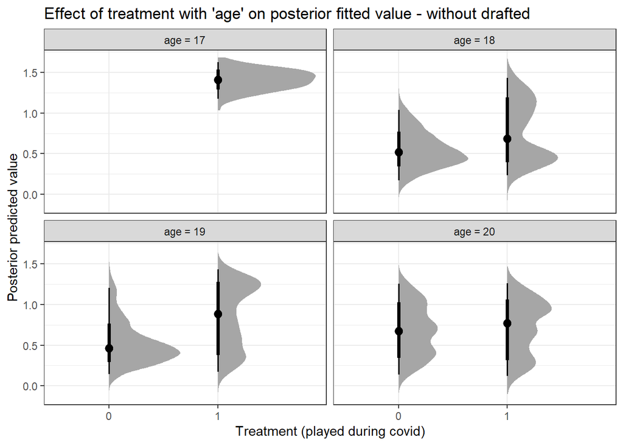

```r
# without draft
treatment_var_and_c1_nodr <- ohl_update2 %>%
  dplyr::select(treatment, age) %>%
  mutate(.row = 1:n(), treatment = as.factor(treatment))
posterior_fitted_nodr %>%
  left_join(treatment_var_and_c1_nodr, by = ".row") %>%
  ggplot() +
  stat_halfeye(aes(x = treatment, y = fit)) +
  facet_wrap(~age, labeller =
               as_labeller( function(x) paste("age =",x) ) ) +
  xlab("Treatment (played during covid)") + ylab("Posterior predicted value") +
  theme_bw() +
  ggtitle("Effect of treatment with 'age' on posterior fitted value - without drafted")
```

I have no idea what’s going on with age = 17

#### Issue

Some players that have drafted = FALSE have a value in the draft_year column. It’s only for about 20 players, the rest with drafted = FALSE have an ‘NA’ in the draft_year column.

### Treatment effects

Posterior conditional (average) treatment effects calculated using **treatment_effects** function. There is an equation showing the equation in the “Calculate Treatment Effects” section of the tidytreatment page, I just don’t know how to write equations in R.

```r
# calculate treatment effects
# sample based (using data from fit) conditional treatment effects,
# posterior draws
posterior_treat_eff <-
  treatment_effects(te_model, treatment = "treatment",
                    # the dataset here needs to match the BART data EXACTLY
                    # which is really annoying...
                    newdata = dplyr::select(ohl_update, gp_19_20, pts_19_20,
                                     age_continuous, pm_relative_19_20,
                                     pm_19_20, is_forward, ppg_19_20,
                                     is_drafted, treatment, prop_score))

# without draft
posterior_treat_eff_nodr <-
  treatment_effects(te_model_nodr, treatment = "treatment",
                    # the dataset here needs to match the BART data EXACTLY
                    # which is really annoying...
                    newdata = dplyr::select(ohl_update2, gp_19_20, pts_19_20,
                                     age_continuous, pm_relative_19_20,
                                     pm_19_20, is_forward, ppg_19_20,
                                     treatment, prop_score))
```

All draws:

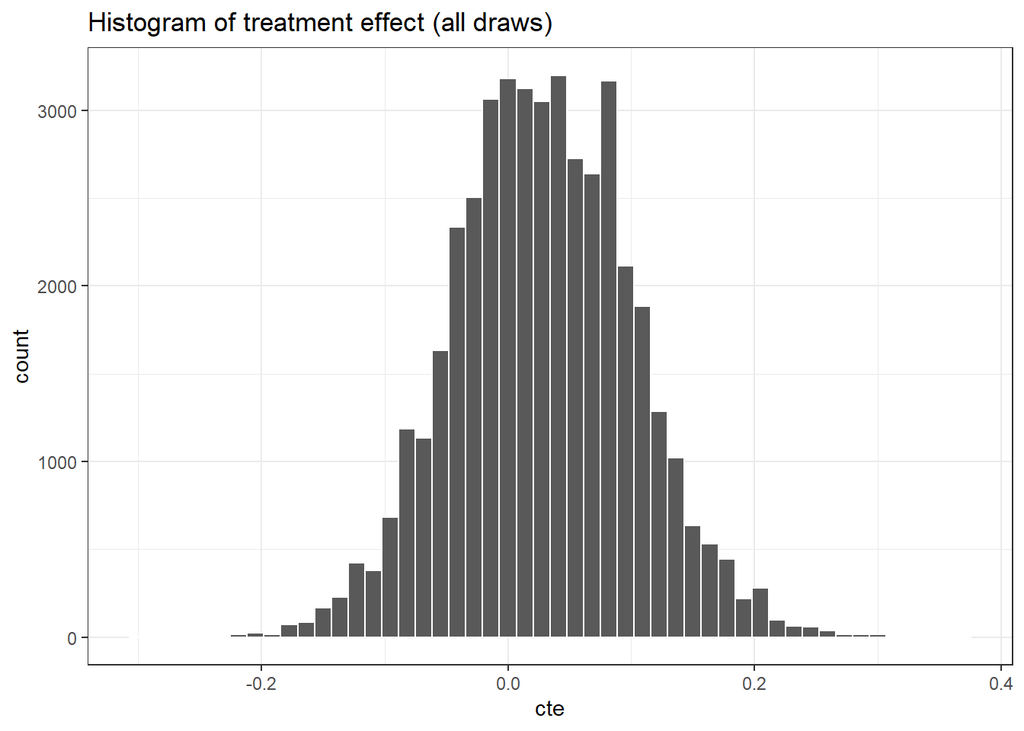

```r
# histogram of treatment effect (all draws)
posterior_treat_eff %>%
  ggplot() +
  geom_histogram(aes(x = cte), bins = 50, color = "white") +
  theme_bw() + ggtitle("Histogram of treatment effect (all draws)")
```

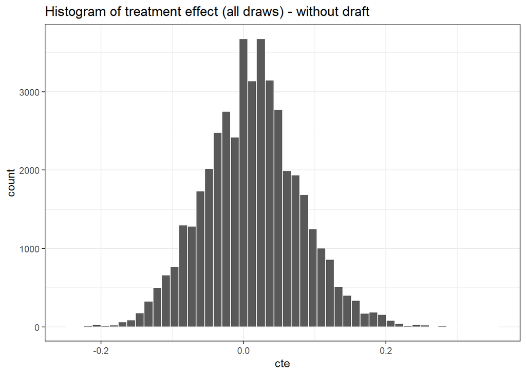

```r
# without draft
posterior_treat_eff_nodr %>%
  ggplot() +
  geom_histogram(aes(x = cte), bins = 50, color = "white") +
  theme_bw() + ggtitle("Histogram of treatment effect (all draws) - without draft")
```

This appears to be normally distributed as the bell-curve looks to be pretty symmetric. The right side may be a bit longer, but it is minimal.

Mean for each subject:

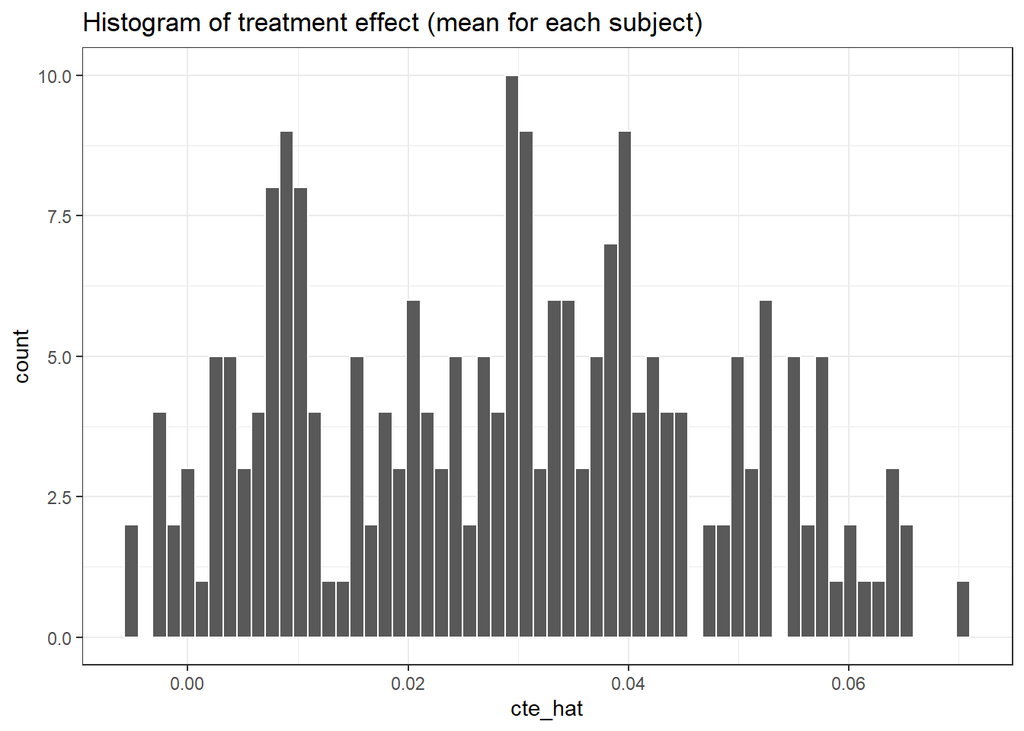

```r
# histogram of treatment effect (mean for each subject)
posterior_treat_eff %>% summarise(cte_hat = mean(cte)) %>%
  ggplot() +
  geom_histogram(aes(x = cte_hat), bins = 60, colour = "white") +
  theme_bw() +
  ggtitle("Histogram of treatment effect (mean for each subject)")
```

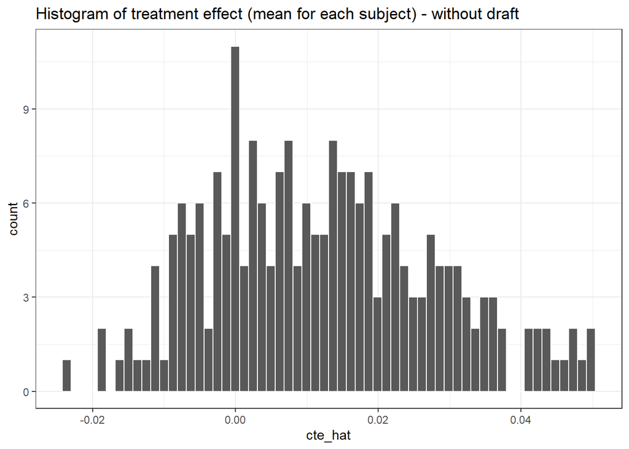

```r
# without draft
posterior_treat_eff_nodr %>% summarise(cte_hat = mean(cte)) %>%
  ggplot() +
  geom_histogram(aes(x = cte_hat), bins = 60, colour = "white") +
  theme_bw() +
  ggtitle("Histogram of treatment effect (mean for each subject) - without draft")
```

Look at the x-axis values for the “without draft” graph

Confidence intervals of the CATEs: stack of each subjects posterior confidence intervals of the CATEs

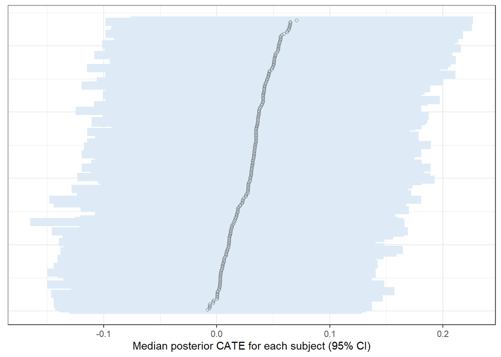

```r
# posterior CIs of the CATEs
posterior_treat_eff %>% select(-treatment) %>% point_interval() %>%
  arrange(cte) %>% mutate(.orow = 1:n()) %>%
  ggplot() +
  geom_interval(aes(x = .orow, y= cte, ymin = .lower, ymax = .upper)) +
  geom_point(aes(x = .orow, y = cte), shape = "circle open", alpha = 0.5) +
  ylab("Median posterior CATE for each subject (95% CI)") +
  theme_bw() + coord_flip() + scale_colour_brewer() +
  theme(axis.title.y = element_blank(),
        axis.text.y = element_blank(),
        axis.ticks.y = element_blank(),
        legend.position = "none")
```

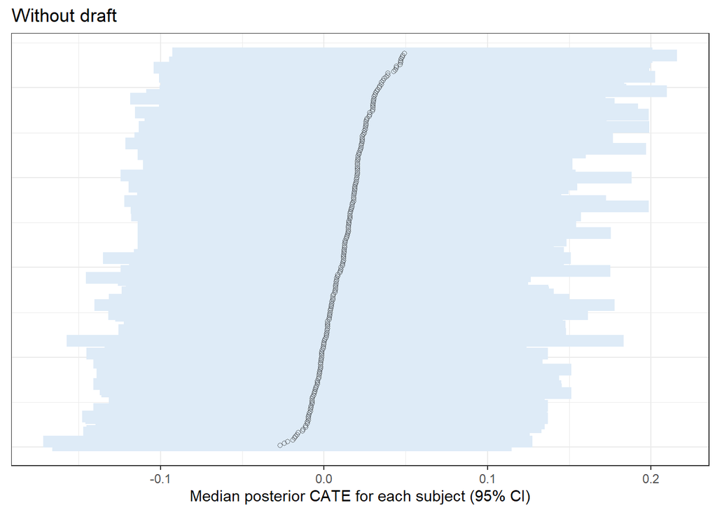

```r
# without draft
posterior_treat_eff_nodr %>% select(-treatment) %>% point_interval() %>%
  arrange(cte) %>% mutate(.orow = 1:n()) %>%
  ggplot() +
  geom_interval(aes(x = .orow, y= cte, ymin = .lower, ymax = .upper)) +
  geom_point(aes(x = .orow, y = cte), shape = "circle open", alpha = 0.5) +
  ylab("Median posterior CATE for each subject (95% CI)") +
  theme_bw() + coord_flip() + scale_colour_brewer() +
  theme(axis.title.y = element_blank(),
        axis.text.y = element_blank(),
        axis.ticks.y = element_blank(),
        legend.position = "none") +
  ggtitle("Without draft")
```

### Investigating variable importance

Variables with treatment:

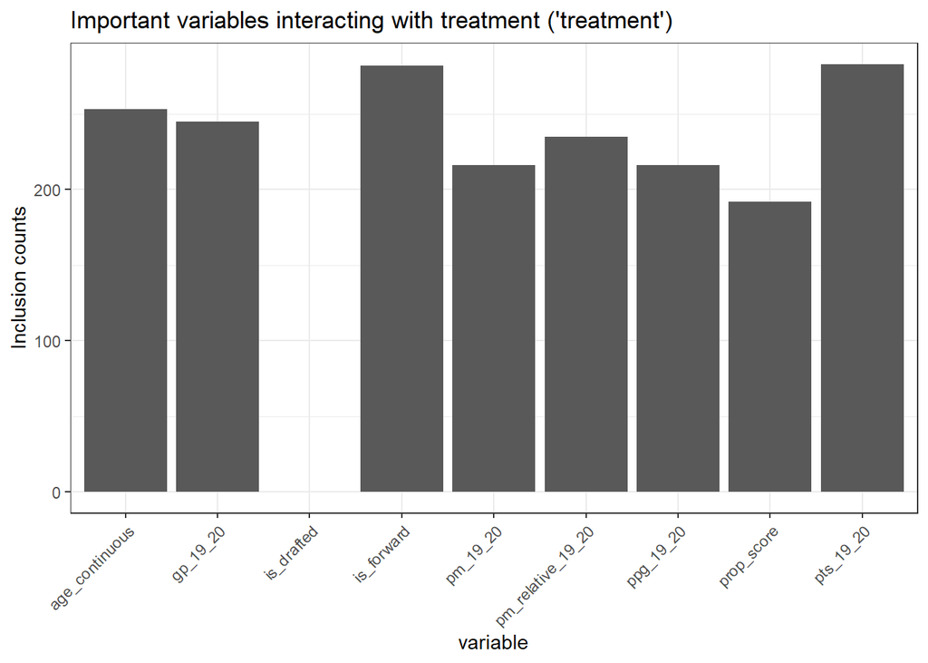

```r
# occurrences of a variable in BART
treatment_interactions <-
  covariate_with_treatment_importance(te_model, treatment = "treatment")

treatment_interactions %>%
  ggplot() +
  geom_bar(aes(x = variable, y = avg_inclusion), stat = "identity") +
  theme_bw() +
  ggtitle("Important variables interacting with treatment ('treatment')") +
  ylab("Inclusion counts") +
  theme(axis.text.x = element_text(angle = 45, hjust=1))
```

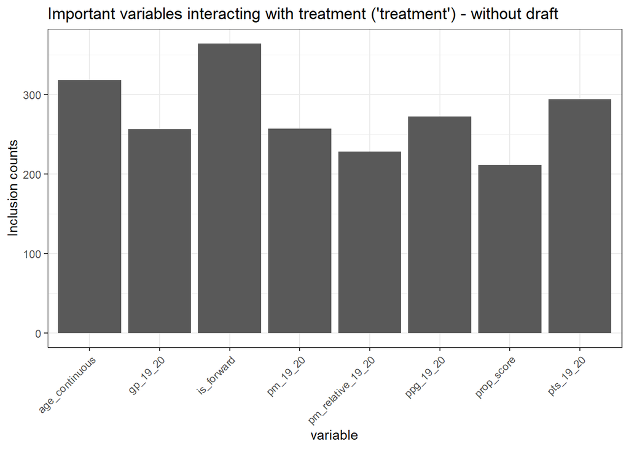

```r
# without draft
treatment_interactions_nodr <-
  covariate_with_treatment_importance(te_model_nodr, treatment = "treatment")

treatment_interactions_nodr %>%
  ggplot() +
  geom_bar(aes(x = variable, y = avg_inclusion), stat = "identity") +
  theme_bw() +
  ggtitle("Important variables interacting with treatment ('treatment') - without draft") +
  ylab("Inclusion counts") +
  theme(axis.text.x = element_text(angle = 45, hjust=1))
```

#### Variables overall:

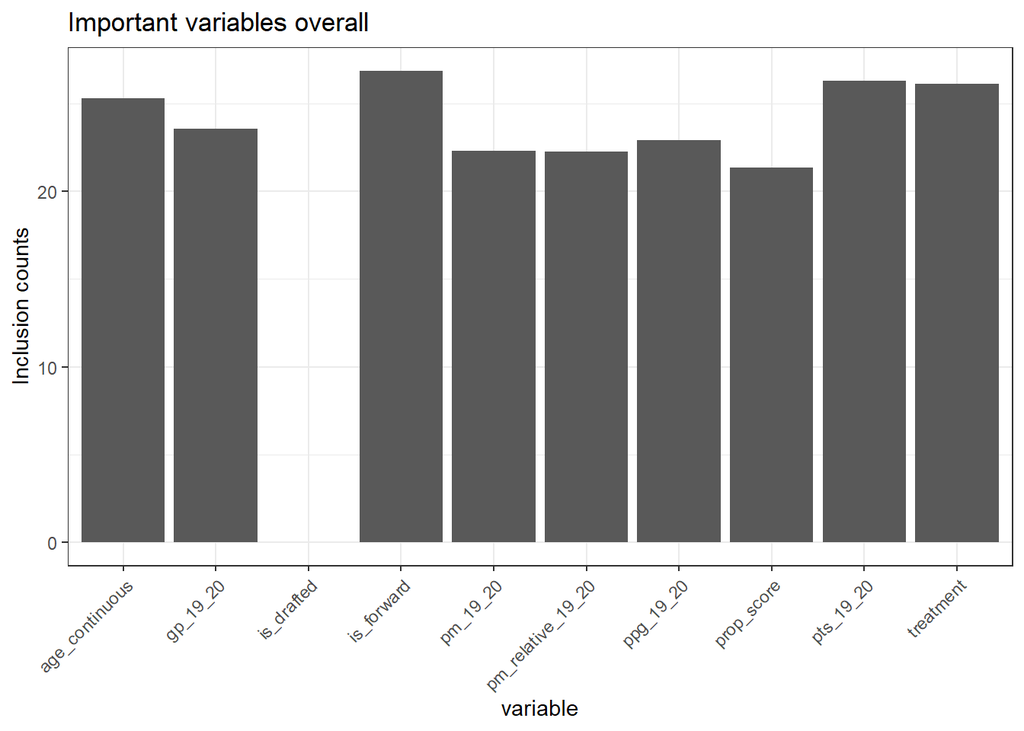

```r
variable_importance <-
  covariate_importance(te_model)

variable_importance %>%
  ggplot() +
  geom_bar(aes(x = variable, y = avg_inclusion), stat = "identity") +
  theme_bw() + ggtitle("Important variables overall") +
  ylab("Inclusion counts") +
  theme(axis.text.x = element_text(angle = 45, hjust=1))
```

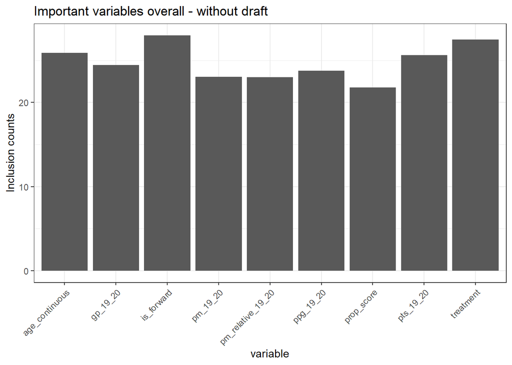

```r
# without draft
variable_importance_nodr <-
  covariate_importance(te_model_nodr)

variable_importance_nodr %>%
  ggplot() +
  geom_bar(aes(x = variable, y = avg_inclusion), stat = "identity") +
  theme_bw() + ggtitle("Important variables overall - without draft") +
  ylab("Inclusion counts") +
  theme(axis.text.x = element_text(angle = 45, hjust=1))
```

Look into:

```r
posterior_treat_eff %>% summarise(cte_hat = mean(cte)) %>%
  filter(abs(cte_hat) > 0.05)
```

```
## # A tibble: 36 × 2
##     .row cte_hat
##    <int>   <dbl>
##  1     5  0.0560
##  2     6  0.0657
##  3    11  0.0554
##  4    15  0.0610
##  5    18  0.0531
##  6    29  0.0547
##  7    30  0.0502
##  8    35  0.0525
##  9    40  0.0547
## 10    52  0.0579
## # … with 26 more rows
```

```r
posterior_treat_eff %>% summarise(cte_hat = mean(cte))
```

```
## # A tibble: 219 × 2
##     .row cte_hat
##    <int>   <dbl>
##  1     1 0.00732
##  2     2 0.0475
##  3     3 0.0197
##  4     4 0.00823
##  5     5 0.0560
##  6     6 0.0657
##  7     7 0.0222
##  8     8 0.0255
##  9     9 0.0437
## 10    10 0.0301
## # … with 209 more rows
```

correlation matrix - make better one

```r
library(Hmisc)
rcorr(as.matrix(select(ohl_update, gp_19_20, pts_19_20, pm_relative_19_20, pm_19_20, ppg_19_20)))
```

```
##                   gp_19_20 pts_19_20 pm_relative_19_20 pm_19_20 ppg_19_20
## gp_19_20              1.00      0.59             -0.09    -0.17      0.38
## pts_19_20             0.59      1.00              0.04    -0.04      0.92
## pm_relative_19_20    -0.09      0.04              1.00     0.63      0.08
## pm_19_20             -0.17     -0.04              0.63     1.00     -0.01
## ppg_19_20             0.38      0.92              0.08    -0.01      1.00
##
## n= 219
##
##
## P
##                   gp_19_20 pts_19_20 pm_relative_19_20 pm_19_20 ppg_19_20
## gp_19_20                   0.0000    0.1965            0.0138   0.0000
## pts_19_20         0.0000             0.5901            0.5890   0.0000
## pm_relative_19_20 0.1965   0.5901                      0.0000   0.2552
## pm_19_20          0.0138   0.5890    0.0000                     0.8490
## ppg_19_20         0.0000   0.0000    0.2552            0.8490
```

Updated correlation matrix in ‘filtering.R’ script

## Regular Regression Tree

Following example from lecture 19 (https://www.stat.cmu.edu/cmsac/sure/2022/materials/lectures/slides/19-Trees.html#1)

```r
library(rpart)
init_tree <- rpart(formula = ppg_21_22 ~ position + ppg_19_20 + treatment + gp_21_22 + age_continuous,
                   data = ohl_update, method = "anova")
```

Display tree

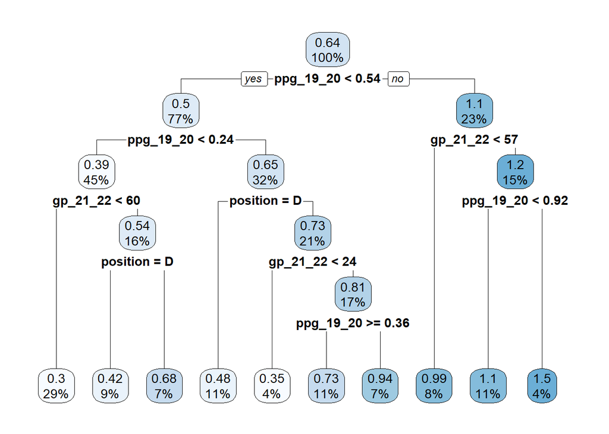

```r
library(rpart.plot)
rpart.plot(init_tree)
```

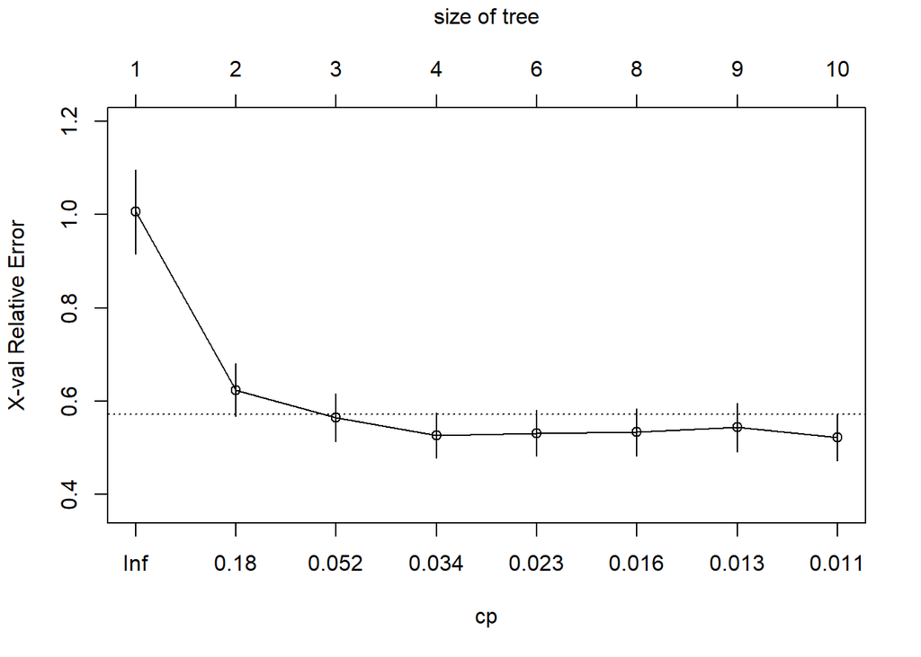

```r
plotcp(init_tree)
```

The bottom number tells you how much of the data is in a particular node. For example, 29% of players in ohl_update had a ppg in the 2019-2020 season less than 0.24 and played less than 60 games in the 2021-2022 season.

Full tree

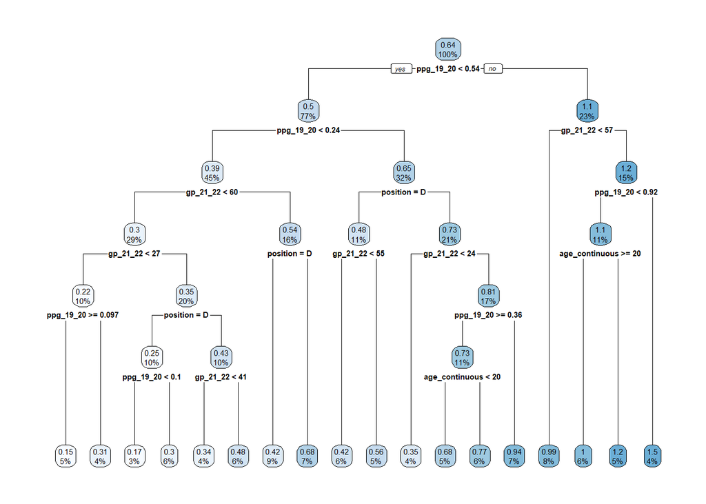

```r
full_tree <- rpart(formula = ppg_21_22 ~ position + ppg_19_20 + treatment + gp_21_22 + age_continuous,
                   data = ohl_update, method = "anova", control = list(cp = 0, xval = 10))
rpart.plot(full_tree)
```

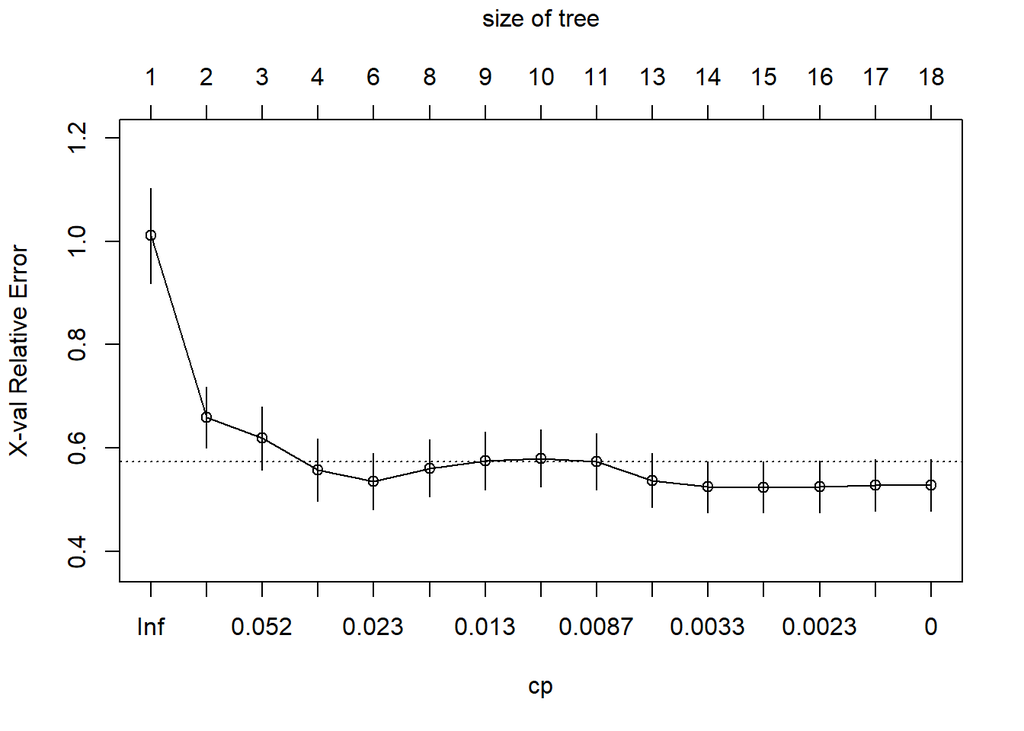

```r
plotcp(full_tree)
```

Not fully sure how to interpret this graph.

Train with caret:

```r
# library(caret)
# caret_tree <- train(formula = ppg_21_22 ~ position + ppg_19_20 + treatment + gp_21_22 + age_continuous+ pts_19_20 + pm_19_20,
#                    data = ohl_update, method = "rpart", trControl = trainControl(method = "cv", number = 10), tuneLength = 20)
# ggplot(caret_tree) + theme_bw()
```

Error in na.fail.default(list(season = c(“2019-2020”, “2019-2020”, “2019-2020”, : missing values in object